# PCA Fluency without strongly correlated measures

Magdalena Grose-Hodge

21/02/2023

load packages

```r
library(tidyverse)
library(broom)
library(Hmisc)
library(factoextra)
```

import, read and merge data as working directory was set for the whole document in the setup code chunk above.

```r
allData <- read_csv("Data_anonymised.csv")
```

check data

```r
summary(allData)
```

```
##  Participant            eMLAT           PNT_pl          PNT_en
##  Length:78          Min.   : 2.00   Min.   :17.00   Min.   :13.00
##  Class :character   1st Qu.: 8.50   1st Qu.:27.50   1st Qu.:20.00
##  Mode  :character   Median :18.00   Median :35.00   Median :25.00
##                     Mean   :15.29   Mean   :38.37   Mean   :27.29
##                     3rd Qu.:21.00   3rd Qu.:44.50   3rd Qu.:32.00
##                     Max.   :26.00   Max.   :84.00   Max.   :50.00
##                     NA's   :3       NA's   :3       NA's   :3
##     Read_pl         Read_en        Age_decim         TROG_pl
##  Min.   : 4.00   Min.   : 5.00   Min.   : 7.250   Min.   :51.00
##  1st Qu.:21.50   1st Qu.:50.50   1st Qu.: 7.917   1st Qu.:68.00
##  Median :35.00   Median :68.00   Median : 8.833   Median :71.00
##  Mean   :35.64   Mean   :63.79   Mean   : 9.160   Mean   :70.80
##  3rd Qu.:45.00   3rd Qu.:80.00   3rd Qu.:10.080   3rd Qu.:74.75
##  Max.   :92.00   Max.   :96.00   Max.   :12.333   Max.   :80.00
##  NA's   :3       NA's   :3       NA's   :1        NA's   :4
##     MLTU_pl        LexDiv_pl       Subindex_pl       DflR_pl
##  Min.   :3.800   Min.   :0.3300   Min.   :1.000   Min.   : 4.140
##  1st Qu.:4.888   1st Qu.:0.4900   1st Qu.:1.110   1st Qu.: 9.162
##  Median :5.445   Median :0.5300   Median :1.160   Median :13.100
##  Mean   :5.529   Mean   :0.5245   Mean   :1.168   Mean   :13.557
##  3rd Qu.:5.997   3rd Qu.:0.5600   3rd Qu.:1.222   3rd Qu.:16.642
##  Max.   :8.150   Max.   :0.6300   Max.   :1.450   Max.   :28.800
##  NA's   :2       NA's   :2        NA's   :2       NA's   :2
##   Retracing_pl   Repetitions_pl     Pauses_pl      Filled_pauses_pl
##  Min.   :0.000   Min.   :0.0000   Min.   : 1.580   Min.   :0.000
##  1st Qu.:0.770   1st Qu.:0.7675   1st Qu.: 5.697   1st Qu.:0.785
##  Median :1.185   Median :1.4950   Median : 6.915   Median :2.090
##  Mean   :1.313   Mean   :1.9270   Mean   : 7.850   Mean   :2.467
##  3rd Qu.:1.705   3rd Qu.:2.7475   3rd Qu.: 9.213   3rd Qu.:3.335
##  Max.   :3.160   Max.   :7.0000   Max.   :19.340   Max.   :9.130
##  NA's   :2       NA's   :2        NA's   :2        NA's   :2
##   Breakdown_pl      Repair_pl     Phonationtime_pl Mean_Length_of_Run_pl
##  Min.   : 2.760   Min.   :0.000   Min.   :33.00    Min.   : 5.92
##  1st Qu.: 7.503   1st Qu.:1.677   1st Qu.:55.35    1st Qu.: 9.74
##  Median : 9.440   Median :2.705   Median :64.11    Median :11.43
##  Mean   :10.318   Mean   :3.240   Mean   :64.11    Mean   :12.17
##  3rd Qu.:12.830   3rd Qu.:4.308   3rd Qu.:73.40    3rd Qu.:13.87
##  Max.   :24.720   Max.   :8.750   Max.   :94.08    Max.   :25.88
##  NA's   :2        NA's   :2       NA's   :2        NA's   :2
```

[output cut: 73 more lines]

```
##  Min.   :0.770   Min.   : 7.220   Min.   : 3.150   Min.   :4.300
##  1st Qu.:1.520   1st Qu.: 7.920   1st Qu.: 5.530   1st Qu.:4.700
##  Median :2.170   Median : 8.800   Median : 6.760   Median :4.900
##  Mean   :2.701   Mean   : 9.081   Mean   : 6.926   Mean   :4.848
##  3rd Qu.:3.340   3rd Qu.: 9.950   3rd Qu.: 8.240   3rd Qu.:5.000
##  Max.   :8.000   Max.   :12.170   Max.   :11.030   Max.   :5.000
##  NA's   :13      NA's   :13       NA's   :13       NA's   :13
##     Qual_en        No_excl_pl
##  Min.   :4.100   Min.   :0.0000
##  1st Qu.:4.900   1st Qu.:0.0000
##  Median :5.000   Median :0.0000
##  Mean   :4.908   Mean   :0.8281
##  3rd Qu.:5.000   3rd Qu.:2.0000
##  Max.   :5.000   Max.   :4.0000
##  NA's   :13      NA's   :14
```

create a dataset for Polish fluency measures only

```r
fluency_pl <-  allData %>%
  select (DflR_pl, Retracing_pl, Repetitions_pl, Pauses_pl, Filled_pauses_pl, Breakdown_pl, Repair_pl, Phonationtime_pl, Mean_Length_of_Run_pl, Speechrate_pl, ArtR_pl, ASD_pl)
```

filter dataset: remove participants with missing values

```r
fluency_pl_1 <- na.omit(fluency_pl)
```

check correlations

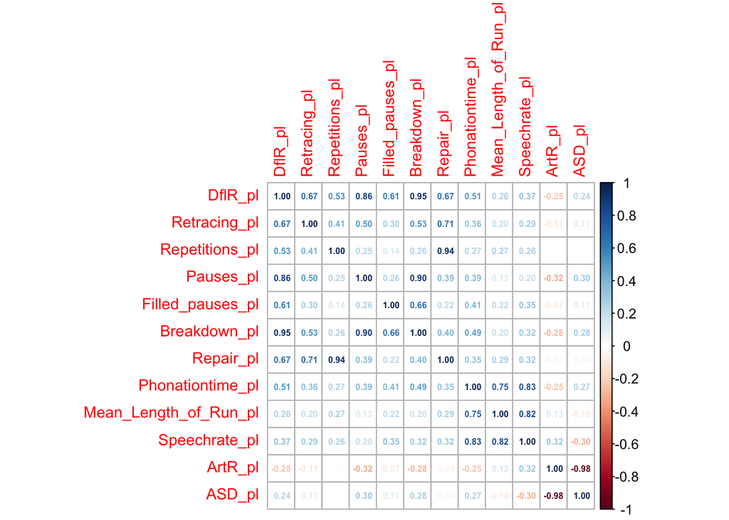

```r
cor_fluency_pl = cor(fluency_pl_1)
library (corrplot)
corrplot(cor_fluency_pl, method="number",number.cex = 0.5, tl.cex = 0.9)
```

# Choosing measures for PCA and creating datasets.

```r
#speed and all dysfluencies only:

fluency_pl_2components <-  fluency_pl_1 %>%
  select (DflR_pl, ArtR_pl)

#speed, breakdown, repair:

fluency_pl_3components <- fluency_pl_1 %>%
  select (Breakdown_pl, ArtR_pl, Repair_pl)


#fluency

fluency_pl_5components <- fluency_pl_1 %>%
  select (ArtR_pl, Filled_pauses_pl, Pauses_pl, Retracing_pl, Repetitions_pl)


#speed, breakdown, repair and composite meausures:

fluency_pl_TavShcomposite <- fluency_pl_1 %>%
  select (Breakdown_pl, ArtR_pl, Repair_pl, Speechrate_pl, Mean_Length_of_Run_pl)
```

#PCA for 2 components:

scaling the data [purpose of scaling is to standardize the variance across variables] and running PCA

```r
pca_pl_2 <- prcomp(fluency_pl_2components, center = TRUE,scale. = TRUE)
```

look at proportion of variance

```r
summary(pca_pl_2)
```

```
## Importance of components:
##                           PC1    PC2
## Standard deviation     1.1159 0.8688
## Proportion of Variance 0.6226 0.3774
## Cumulative Proportion  0.6226 1.0000
```

explain variance

```r
var_explained_pl_2 <- pca_pl_2$sdev^2 / sum(pca_pl_2$sdev^2)
var_explained_pl_2
```

```
## [1] 0.6225728 0.3774272
```

```
## `geom_line()`: Each group consists of only one observation.
## ℹ Do you need to adjust the group aesthetic?
```

[figure not shown]

```r
qplot(c(1:2), var_explained_pl_2) +
  geom_line() +
  xlab("Principal Component") +
  ylab("Variance Explained") +
  ggtitle("Scree Plot") +
  ylim(0, 0.40)
```

Eigenvalue [The idea behind this is that if the eigenvalue is less than 1, then the component accounts for less variance than a single variable contributed]

```r
pca_pl_2$sdev ^ 2
```

```
## [1] 1.2451456 0.7548544
```

which variables contribute to any given component

```r
print(pca_pl_2$rotation)
```

```
##                PC1       PC2
## DflR_pl -0.7071068 0.7071068
## ArtR_pl  0.7071068 0.7071068
```

another way of plotting the results and looking at the contributions

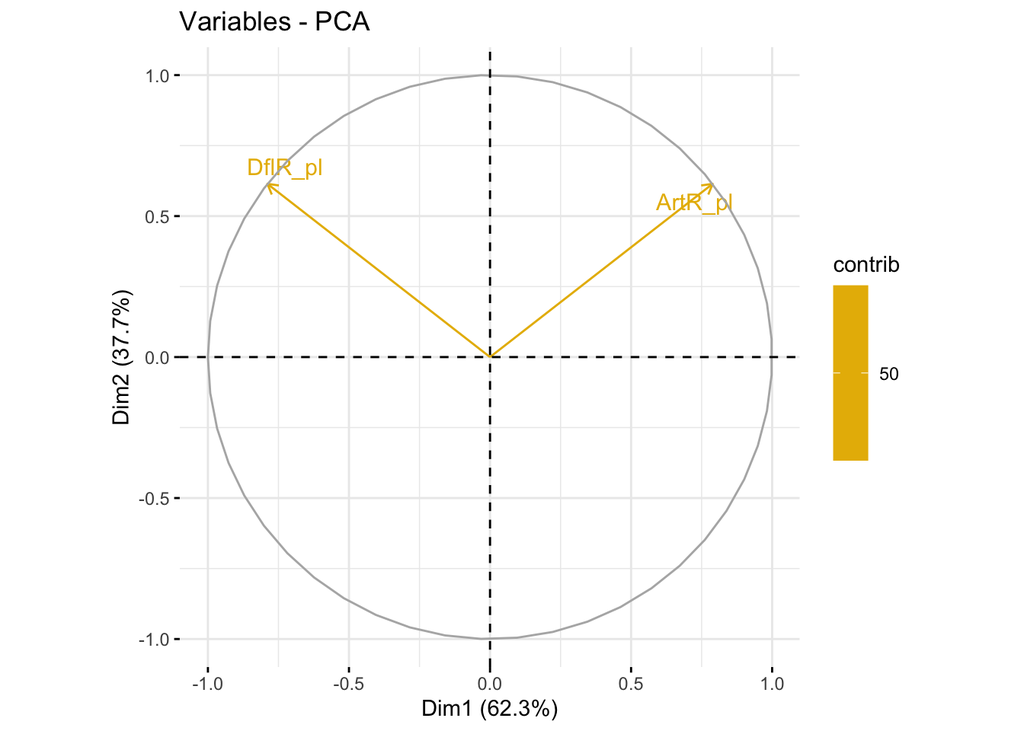

```r
fviz_pca_var(pca_pl_2,
             col.var = "contrib", # Color by contributions to the PC
             gradient.cols = c("#00AFBB", "#E7B800", "#FC4E07"),
             repel = TRUE)    # Avoid text overlapping
```

#PCA for 3 components:

scaling the data [purpose of scaling is to standardize the variance across variables] and running PCA

```r
pca_pl_3 <- prcomp(fluency_pl_3components, center = TRUE,scale. = TRUE)
```

look at proportion of variance

```r
summary(pca_pl_3)
```

```
## Importance of components:
##                           PC1    PC2    PC3
## Standard deviation     1.2298 0.9808 0.7250
## Proportion of Variance 0.5041 0.3206 0.1752
## Cumulative Proportion  0.5041 0.8248 1.0000
```

explain variance

```r
var_explained_pl_3 <- pca_pl_3$sdev^2 / sum(pca_pl_3$sdev^2)
var_explained_pl_3
```

```
## [1] 0.5041490 0.3206464 0.1752046
```

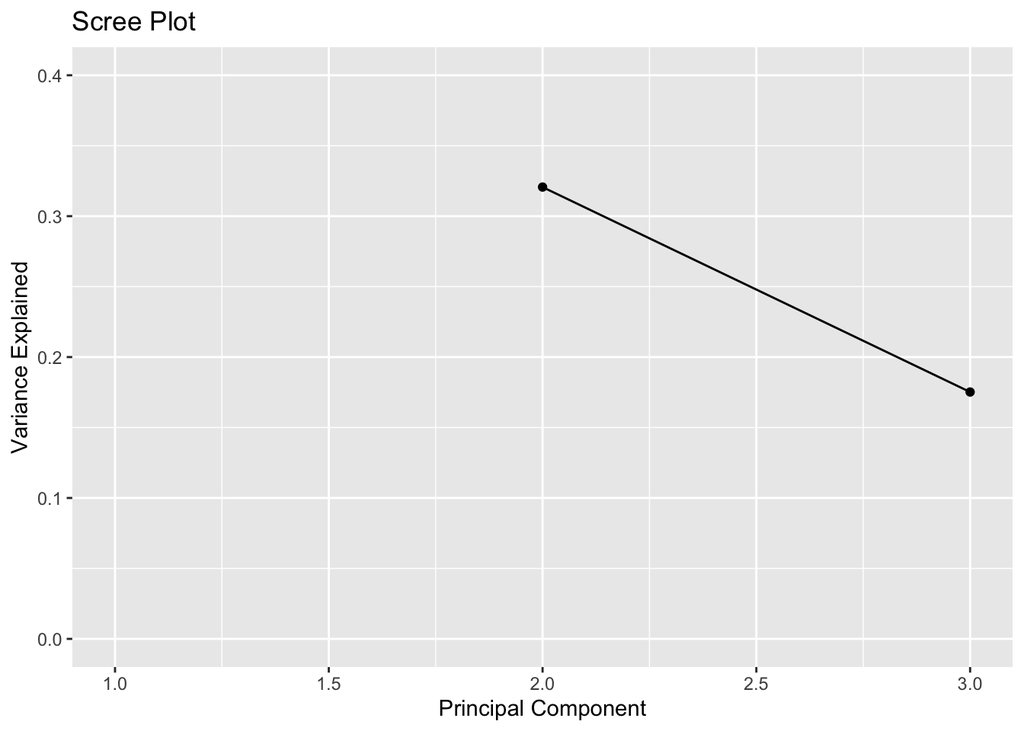

```r
qplot(c(1:3), var_explained_pl_3) +
  geom_line() +
  xlab("Principal Component") +
  ylab("Variance Explained") +
  ggtitle("Scree Plot") +
  ylim(0, 0.40)
```

Eigenvalue [The idea behind this is that if the eigenvalue is less than 1, then the component accounts for less variance than a single variable contributed]

```r
pca_pl_3$sdev ^ 2
```

```
## [1] 1.5124470 0.9619391 0.5256139
```

which variables contribute to any given component

```r
print(pca_pl_3$rotation)
```

```
##                     PC1        PC2        PC3
## Breakdown_pl -0.6930956 0.02749092  0.7203213
## ArtR_pl       0.4308697 0.81691523  0.3834069
## Repair_pl    -0.5779012 0.57610221 -0.5780453
```

another way of plotting the results and looking at the contributions

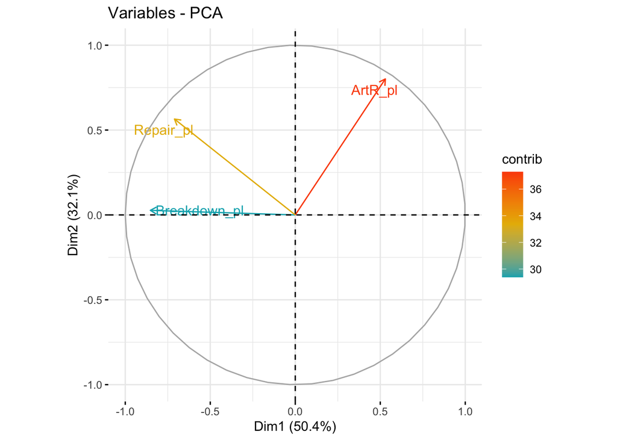

```r
fviz_pca_var(pca_pl_3,
             col.var = "contrib", # Color by contributions to the PC
             gradient.cols = c("#00AFBB", "#E7B800", "#FC4E07"),
             repel = TRUE)    # Avoid text overlapping
```

# PCA with 5 components

scaling the data [purpose of scaling is to standardize the variance across variables] and running PCA

```r
pca_pl_5 <- prcomp(fluency_pl_5components, center = TRUE,scale. = TRUE)
```

look at proportion of variance

```r
summary(pca_pl_5)
```

```
## Importance of components:
##                           PC1    PC2    PC3    PC4     PC5
## Standard deviation     1.4260 1.0336 0.9263 0.7802 0.65677
## Proportion of Variance 0.4067 0.2137 0.1716 0.1217 0.08627
## Cumulative Proportion  0.4067 0.6204 0.7920 0.9137 1.00000
```

explain variance

```r
var_explained_pl_5 <- pca_pl_5$sdev^2 / sum(pca_pl_5$sdev^2)
var_explained_pl_5
```

```
## [1] 0.40670503 0.21368159 0.17161365 0.12173095 0.08626878
```

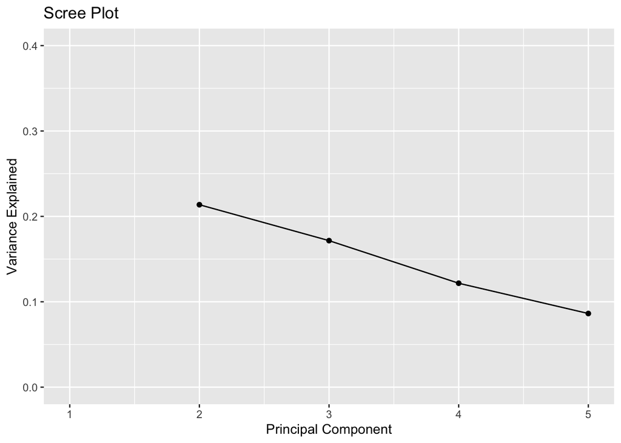

```r
qplot(c(1:5), var_explained_pl_5) +
  geom_line() +
  xlab("Principal Component") +
  ylab("Variance Explained") +
  ggtitle("Scree Plot") +
  ylim(0, 0.40)
```

Eigenvalue [The idea behind this is that if the eigenvalue is less than 1, then the component accounts for less variance than a single variable contributed]

```r
pca_pl_5$sdev ^ 2
```

```
## [1] 2.0335251 1.0684079 0.8580683 0.6086548 0.4313439
```

which variables contribute to any given component

```r
print(pca_pl_5$rotation)
```

```
##                         PC1         PC2         PC3        PC4        PC5
## ArtR_pl          -0.2588532 -0.80406318  0.17498641 -0.4528550 -0.2253431
## Filled_pauses_pl  0.3742162 -0.08657189  0.87027259  0.3034353 -0.0549565
## Pauses_pl         0.5499630  0.25140326 -0.08406273 -0.4795815 -0.6302952
## Retracing_pl      0.5680789 -0.19641763 -0.09265436 -0.3630399  0.7059205
## Repetitions_pl    0.4096149 -0.49417023 -0.44311850  0.5839974 -0.2249543
```

another way of plotting the results and looking at the contributions

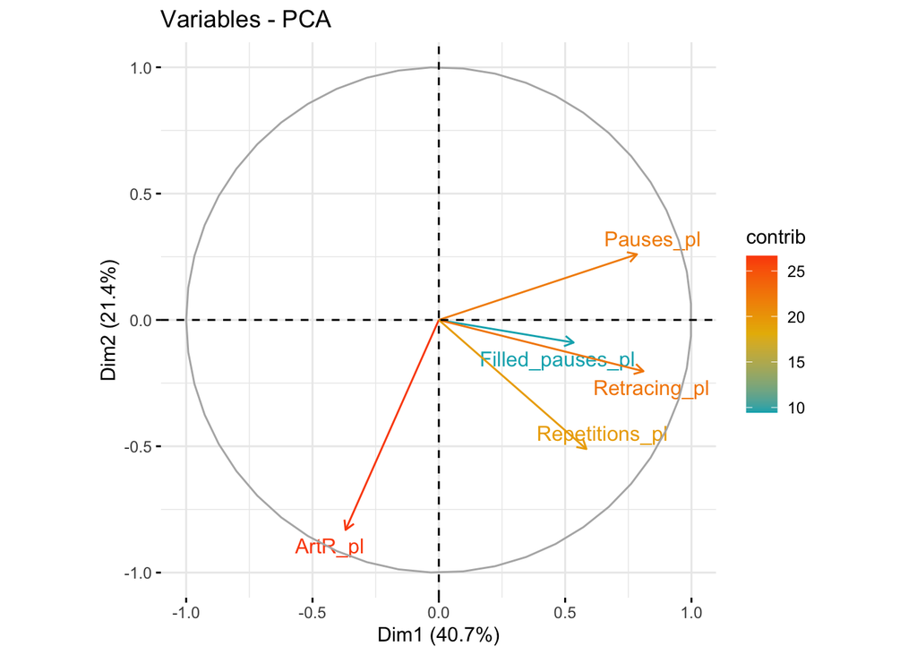

```r
fviz_pca_var(pca_pl_5,
             col.var = "contrib", # Color by contributions to the PC
             gradient.cols = c("#00AFBB", "#E7B800", "#FC4E07"),
             repel = TRUE)    # Avoid text overlapping
```

# PCA with 5 components following Tavakoli and Skehan (2005) and overall composite measures.

scaling the data [purpose of scaling is to standardize the variance across variables] and running PCA

```r
pca_pl_TavShcomposite <- prcomp(fluency_pl_TavShcomposite, center = TRUE,scale. = TRUE)
```

```r
summary(fluency_pl_TavShcomposite)
```

```
##   Breakdown_pl       ArtR_pl        Repair_pl     Speechrate_pl
##  Min.   : 2.760   Min.   :3.060   Min.   :0.000   Min.   :0.960
##  1st Qu.: 7.503   1st Qu.:3.935   1st Qu.:1.677   1st Qu.:1.927
##  Median : 9.440   Median :4.180   Median :2.705   Median :2.210
##  Mean   :10.318   Mean   :4.192   Mean   :3.240   Mean   :2.213
##  3rd Qu.:12.830   3rd Qu.:4.540   3rd Qu.:4.308   3rd Qu.:2.490
##  Max.   :24.720   Max.   :5.340   Max.   :8.750   Max.   :3.650
##  Mean_Length_of_Run_pl
##  Min.   : 5.92
##  1st Qu.: 9.74
##  Median :11.43
##  Mean   :12.17
##  3rd Qu.:13.87
##  Max.   :25.88
```

explain variance

```r
var_explained_pl_TavShcomposite <- pca_pl_TavShcomposite$sdev^2 / sum(pca_pl_TavShcomposite$sdev^2)
var_explained_pl_TavShcomposite
```

```
## [1] 0.44600721 0.27839844 0.14403362 0.10694846 0.02461227
```

[figure not shown]

```r
qplot(c(1:5), var_explained_pl_5) +
  geom_line() +
  xlab("Principal Component") +
  ylab("Variance Explained") +
  ggtitle("Scree Plot") +
  ylim(0, 0.40)
```

Eigenvalue [The idea behind this is that if the eigenvalue is less than 1, then the component accounts for less variance than a single variable contributed]

```r
pca_pl_TavShcomposite$sdev ^ 2
```

```
## [1] 2.2300360 1.3919922 0.7201681 0.5347423 0.1230614
```

which variables contribute to any given component

```r
print(pca_pl_TavShcomposite$rotation)
```

```
##                              PC1        PC2          PC3        PC4         PC5
## Breakdown_pl          -0.3523824 -0.5655870  0.005894412 -0.7131453 -0.21754772
## ArtR_pl               -0.1252589  0.6953292 -0.514703977 -0.4187502 -0.24608061
## Repair_pl             -0.4016030 -0.3315314 -0.726559913  0.4474874  0.02584018
## Speechrate_pl         -0.6094548  0.2304309  0.195051826 -0.1014727  0.72603343
## Mean_Length_of_Run_pl -0.5722034  0.1833500  0.411230532  0.3248544 -0.60359347
```

another way of plotting the results and looking at the contributions

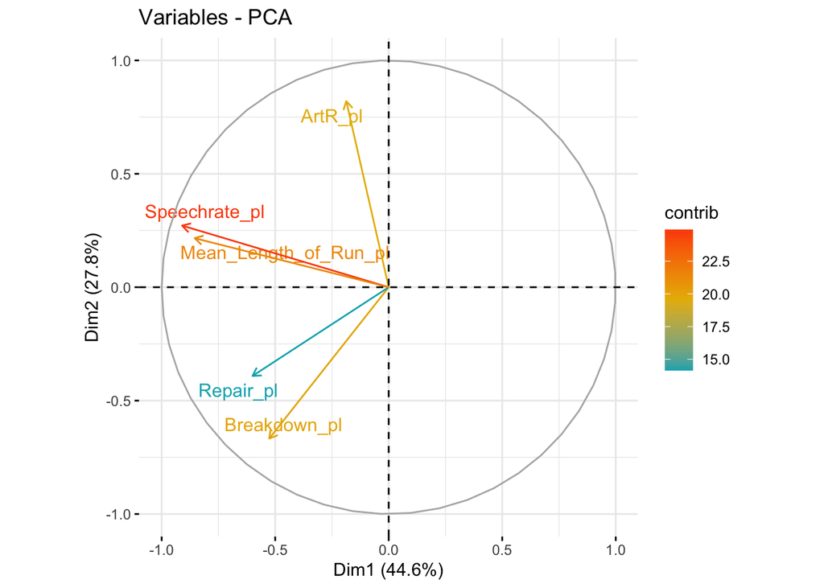

```r
fviz_pca_var(pca_pl_TavShcomposite,
             col.var = "contrib", # Color by contributions to the PC
             gradient.cols = c("#00AFBB", "#E7B800", "#FC4E07"),
             repel = TRUE)    # Avoid text overlapping
```

create a dataset for English fluency measures only

```r
fluency_en <-  allData %>%
  select (DflR_en, Retracing_en, Repetitions_en, Pauses_en, Filled_pauses_en, Breakdown_en, Repair_en, Phonationtime_en, Mean_Length_of_run_en, Speechrate_en, ArtR_en, ASD_en)
```

filter dataset: remove participants with missing values

```r
fluency_en_1 <- na.omit(fluency_en)
```

check correlations

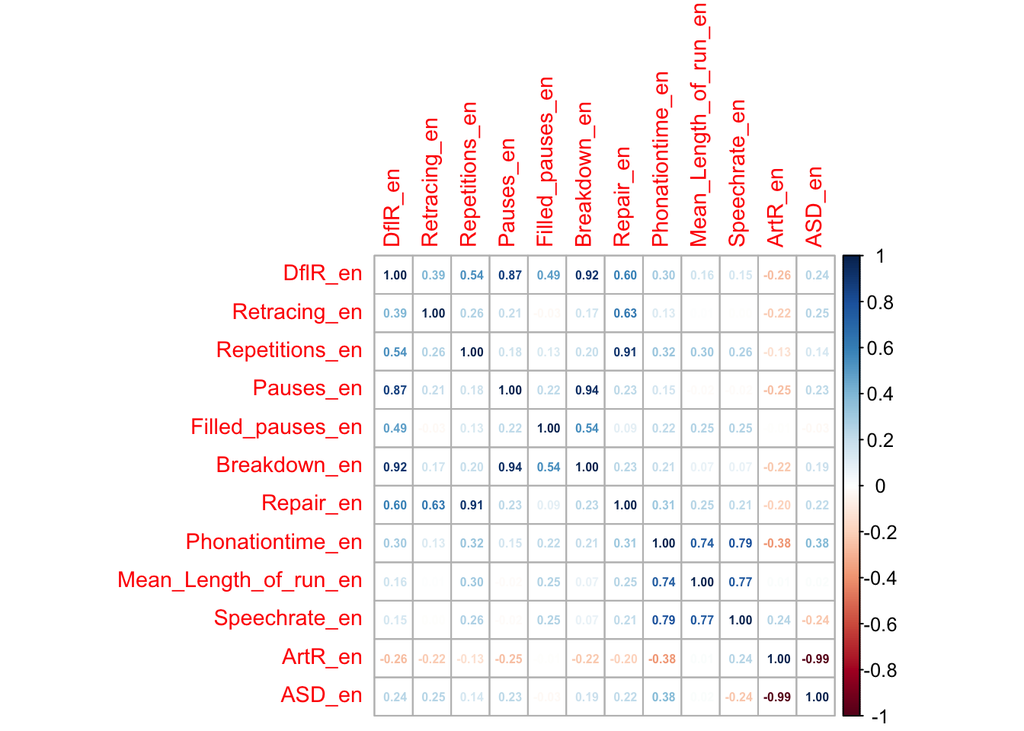

```r
cor_fluency_en = cor(fluency_en_1)
library (corrplot)
corrplot(cor_fluency_en, method="number",number.cex = 0.5, tl.cex = 0.9)
```

# Choosing measures for PCA and creating datasets.

```r
#fluency

fluency_en_5components <- fluency_en_1 %>%
  select (ArtR_en, Filled_pauses_en, Pauses_en, Retracing_en, Repetitions_en)


#speed, breakdown, repair and composite meausures:

fluency_en_TavShcomposite <- fluency_en_1 %>%
  select (Breakdown_en, ArtR_en, Repair_en, Speechrate_en, Mean_Length_of_run_en)
```

# PCA with 5 components

scaling the data [purpose of scaling is to standardize the variance across variables] and running PCA

```r
pca_en_5 <- prcomp(fluency_en_5components, center = TRUE,scale. = TRUE)
```

look at proportion of variance

```r
summary(pca_en_5)
```

```
## Importance of components:
##                           PC1    PC2    PC3    PC4    PC5
## Standard deviation     1.2909 1.0381 0.9504 0.8430 0.8012
## Proportion of Variance 0.3333 0.2155 0.1807 0.1421 0.1284
## Cumulative Proportion  0.3333 0.5488 0.7295 0.8716 1.0000
```

explain variance

```r
var_explained_en_5 <- pca_en_5$sdev^2 / sum(pca_en_5$sdev^2)
var_explained_en_5
```

```
## [1] 0.3333021 0.2155141 0.1806673 0.1421293 0.1283872
```

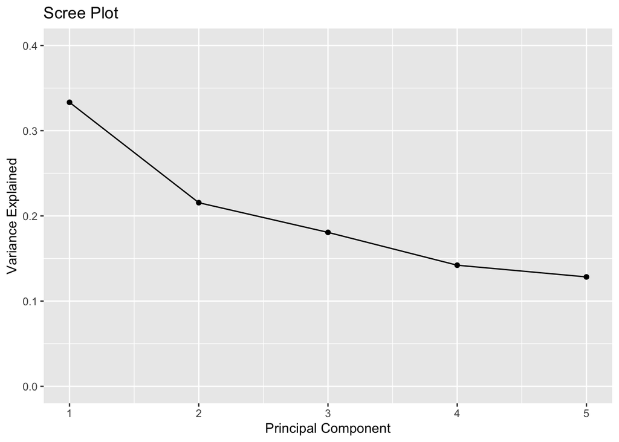

```r
qplot(c(1:5), var_explained_en_5) +
  geom_line() +
  xlab("Principal Component") +
  ylab("Variance Explained") +
  ggtitle("Scree Plot") +
  ylim(0, 0.40)
```

Eigenvalue [The idea behind this is that if the eigenvalue is less than 1, then the component accounts for less variance than a single variable contributed]

```r
pca_en_5$sdev ^ 2
```

```
## [1] 1.6665107 1.0775703 0.9033364 0.7106464 0.6419361
```

which variables contribute to any given component

```r
print(pca_en_5$rotation)
```

```
##                         PC1         PC2         PC3         PC4        PC5
## ArtR_en          -0.4543160 -0.29471408  0.57730114 -0.56110142 -0.2421347
## Filled_pauses_en  0.2497529 -0.82131748  0.02750616  0.03703461  0.5108159
## Pauses_en         0.5285082 -0.24140115 -0.36337557 -0.41749950 -0.5967050
## Retracing_en      0.4844485  0.42437660  0.27068934 -0.53947308  0.4700109
## Repetitions_en    0.4660571 -0.01453255  0.67871369  0.46739341 -0.3216687
```

another way of plotting the results and looking at the contributions

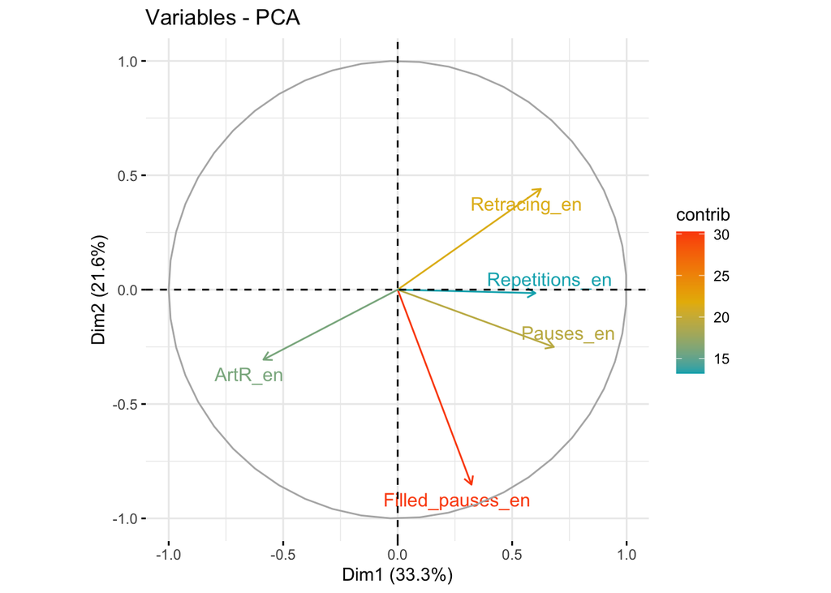

```r
fviz_pca_var(pca_en_5,
             col.var = "contrib", # Color by contributions to the PC
             gradient.cols = c("#00AFBB", "#E7B800", "#FC4E07"),
             repel = TRUE)    # Avoid text overlapping
```

# PCA with 5 components following Tavakoli and Skehan (2005) and overall composite measures.

scaling the data [purpose of scaling is to standardize the variance across variables] and running PCA

```r
pca_en_TavShcomposite <- prcomp(fluency_en_TavShcomposite, center = TRUE,scale. = TRUE)
```

```r
summary(fluency_en_TavShcomposite)
```

```
##   Breakdown_en       ArtR_en        Repair_en     Speechrate_en
##  Min.   : 2.840   Min.   :3.230   Min.   :0.000   Min.   :1.210
##  1st Qu.: 6.492   1st Qu.:4.020   1st Qu.:1.715   1st Qu.:2.232
##  Median : 8.595   Median :4.480   Median :2.525   Median :2.415
##  Mean   : 9.247   Mean   :4.361   Mean   :3.007   Mean   :2.394
##  3rd Qu.:11.010   3rd Qu.:4.652   3rd Qu.:3.777   3rd Qu.:2.630
##  Max.   :21.630   Max.   :5.180   Max.   :8.290   Max.   :3.240
##  Mean_Length_of_run_en
##  Min.   : 5.22
##  1st Qu.:11.19
##  Median :12.91
##  Mean   :13.43
##  3rd Qu.:14.75
##  Max.   :31.53
```

explain variance

```r
var_explained_en_TavShcomposite <- pca_en_TavShcomposite$sdev^2 / sum(pca_en_TavShcomposite$sdev^2)
var_explained_en_TavShcomposite
```

```
## [1] 0.38495913 0.28156062 0.15525535 0.13937777 0.03884714
```

[figure not shown]

```r
qplot(c(1:5), var_explained_en_5) +
  geom_line() +
  xlab("Principal Component") +
  ylab("Variance Explained") +
  ggtitle("Scree Plot") +
  ylim(0, 0.40)
```

Eigenvalue [The idea behind this is that if the eigenvalue is less than 1, then the component accounts for less variance than a single variable contributed]

```r
pca_en_TavShcomposite$sdev ^ 2
```

```
## [1] 1.9247956 1.4078031 0.7762767 0.6968888 0.1942357
```

which variables contribute to any given component

```r
print(pca_en_TavShcomposite$rotation)
```

```
##                               PC1         PC2         PC3         PC4
## Breakdown_en          -0.17751034  0.54882860 -0.81143603  0.06995818
## ArtR_en               -0.05975125 -0.65826176 -0.46151295 -0.54584768
## Repair_en             -0.35355569  0.44679981  0.31575455 -0.75844672
## Speechrate_en         -0.64843263 -0.23841673 -0.06452026  0.11561966
## Mean_Length_of_run_en -0.64765219 -0.09490004  0.15720550  0.32946445
##                               PC5
## Breakdown_en          -0.06288617
## ArtR_en               -0.22842362
## Repair_en             -0.02063825
## Speechrate_en          0.71074736
## Mean_Length_of_run_en -0.66202736
```

another way of plotting the results and looking at the contributions

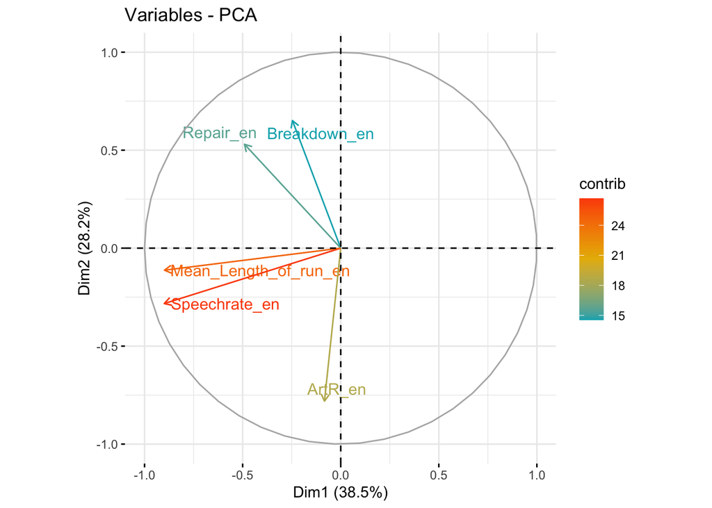

```r
fviz_pca_var(pca_en_TavShcomposite,
             col.var = "contrib", # Color by contributions to the PC
             gradient.cols = c("#00AFBB", "#E7B800", "#FC4E07"),
             repel = TRUE)    # Avoid text overlapping
```